# Graded Project

#### 16. Apply Agglomerative clustering and segment the data. (You may use original data or PCA transformed data)

- a) Find the optimal K Value using dendrogram for Agglomerative clustering.
- b) Build a Agglomerative clustering model using the obtained optimal K value observed from dendrogram.
- c) Compute silhouette score for evaluating the quality of the Agglomerative clustering technique.

  (Hint: Take a sample of the dataset for agglomerative clustering to reduce the computational time)

##### a) Finding the optimal K-value using Dendrogram for Agglomerative clustering

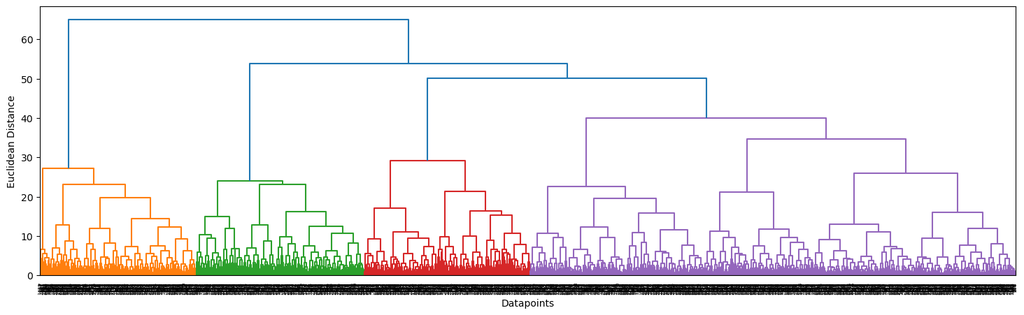

```python
## Dendrogram
plt.figure(figsize=[18,5])
merg = linkage(df_sample, method='ward')
dendrogram(merg, leaf_rotation=90)
plt.xlabel('Datapoints')
plt.ylabel('Euclidean Distance')
plt.show()
```

- From the above Dendrogram, we see that around Euclidean Distance = 60, the vertical distances that are not cutting their horizontal bars are maximum (=2), hence according to this, the optimal number of clusters K = 2 (the vertical lines in this range).

##### b) Building and training the hierarchical model on sample dataset using K=2

```python
## Building and training hierarchical clustering model using K=2
hc = AgglomerativeClustering(n_clusters=2, affinity='euclidean', linkage='ward')
hc_model = hc.fit(df_sample)
```

```python
# Creating dataframe of the labels
df_label1 = pd.DataFrame(hc_model.labels_, columns=['Labels'])
df_label1.sample(5)
```

|  | Labels |
| --- | --- |
| 1968 | 0 |
| 1826 | 0 |
| 1919 | 0 |
| 481 | 1 |
| 1034 | 1 |

```python
# Joining the label dataframe with the initial unscaled dataframe df
df_hier = df_cleaned.join(df_label1)

# Dropping rows with Label = null
df_hier = df_hier.loc[df_hier['Labels'].notnull()]
df_hier['Labels'] = df_hier['Labels'].astype(int)
df_hier.head(5)
```

|  | fit | bust size | weight | rating | rented for | body type | category | height | size | age | Labels |
| --- | --- | --- | --- | --- | --- | --- | --- | --- | --- | --- | --- |
| 0 | fit | 34d | 137.0 | 10.0 | vacation | hourglass | romper | 68.0 | 14 | 28.0 | 0 |
| 1 | fit | 34b | 132.0 | 10.0 | other | straight & narrow | gown | 66.0 | 12 | 36.0 | 0 |
| 3 | fit | 34c | 135.0 | 8.0 | formal affair | pear | dress | 65.0 | 8 | 34.0 | 0 |
| 4 | fit | 34b | 145.0 | 10.0 | wedding | athletic | gown | 69.0 | 12 | 27.0 | 0 |
| 5 | fit | 32b | 138.0 | 8.0 | date | athletic | dress | 68.0 | 8 | 45.0 | 0 |

##### c) Computing Silhouette Score for Agglomerative clustering

```python
for i in range(2,15):
    hier = AgglomerativeClustering(n_clusters=i)
    hier = hier.fit(df_sample)
    labels = hier.fit_predict(df_sample)
    silhouette_avg = silhouette_score(df_sample, labels)
    print('For n_clusters =', i,"average silhouette_score is :", silhouette_avg)
```

```
For n_clusters = 2 average silhouette_score is : 0.1660014736768228
For n_clusters = 3 average silhouette_score is : 0.13831644758727346
For n_clusters = 4 average silhouette_score is : 0.13994799023277182
For n_clusters = 5 average silhouette_score is : 0.09830200798546605
For n_clusters = 6 average silhouette_score is : 0.087260113586958
For n_clusters = 7 average silhouette_score is : 0.08905893831009215
For n_clusters = 8 average silhouette_score is : 0.09188884645246523
For n_clusters = 9 average silhouette_score is : 0.06856465279593678
For n_clusters = 10 average silhouette_score is : 0.07416333996901216
For n_clusters = 11 average silhouette_score is : 0.07830247062782439
For n_clusters = 12 average silhouette_score is : 0.08436580667827182
For n_clusters = 13 average silhouette_score is : 0.08915080197563788
For n_clusters = 14 average silhouette_score is : 0.09194333360651567
```

- From the above results, we can observe once again that cluster 2 has the highest Silhouette score, which confirms the optimal K value observed from the dendrogram.

## V. Conclusions

```python
df_hier.sample(5)
```

|  | fit | bust size | weight | rating | rented for | body type | category | height | size | age | Labels |
| --- | --- | --- | --- | --- | --- | --- | --- | --- | --- | --- | --- |
| 788 | small | 34c | 124.0 | 6.0 | party | athletic | romper | 67.0 | 4 | 38.0 | 0 |
| 1075 | fit | 34c | 140.0 | 10.0 | party | hourglass | romper | 68.0 | 12 | 31.0 | 0 |
| 1514 | large | 34dd | 135.0 | 8.0 | everyday | hourglass | shirtdress | 67.0 | 20 | 30.0 | 0 |
| 1672 | fit | 34a | 130.0 | 10.0 | wedding | hourglass | dress | 66.0 | 8 | 30.0 | 0 |
| 536 | fit | 34b | 140.0 | 10.0 | vacation | full bust | jumpsuit | 68.0 | 8 | 38.0 | 0 |

#### 17. Perform cluster analysis by doing bivariate analysis between cluster labels and different features and write your conclusion on the results.

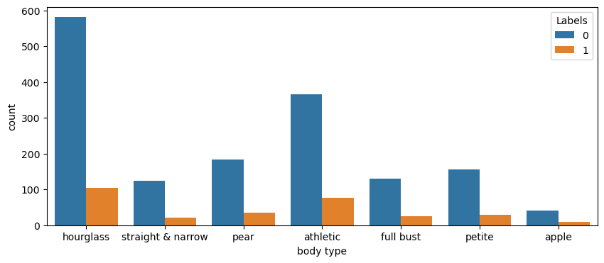

```python
plt.figure(figsize=[10, 4])
sns.countplot(df_hier['body type'], hue='Labels', data=df_hier)
plt.show()
```

- We can observe that most of the customers in cluster 0 have hourglass body-type, followed by athletic body-type.

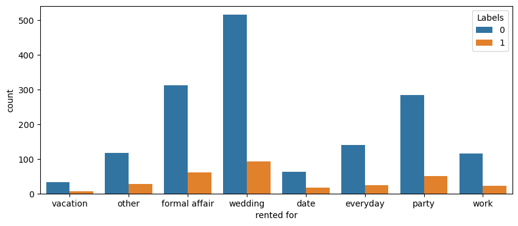

```python
plt.figure(figsize=[10, 4])
sns.countplot(df_hier['rented for'], hue='Labels', data=df_hier)
plt.show()
```

- Under each occasion, the highest number of customers are from cluster 0.
- 'Wedding' has the highest number of purchases, followed by 'formal affair' and 'party'.

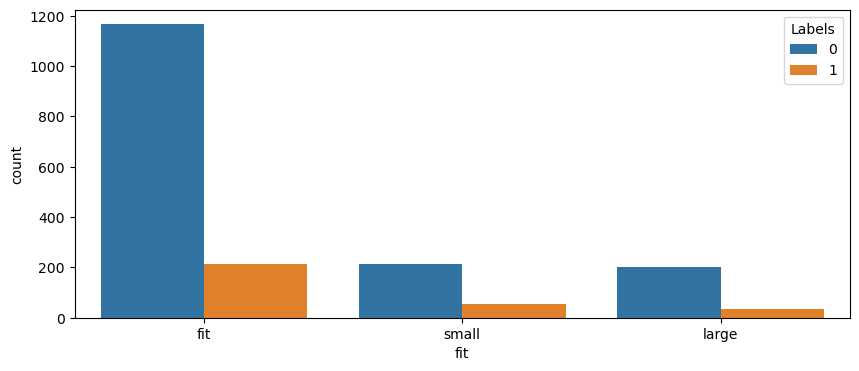

```python
plt.figure(figsize=[10, 4])
sns.countplot(df_hier['fit'], hue='Labels', data=df_hier)
plt.show()
```

- Highest fit-type in cluster 0 and 1 is 'fit'.
- Cluster 0 has higher number of customers than cluster 1.

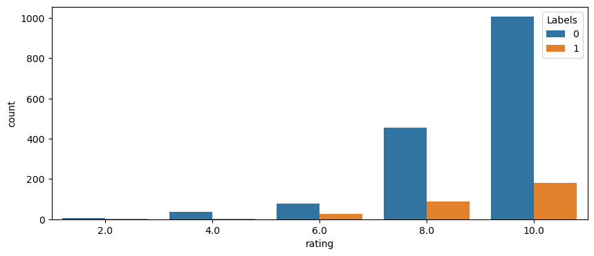

```python
plt.figure(figsize=[10, 4])
sns.countplot(df_hier['rating'], hue='Labels', data=df_hier)
plt.show()
```

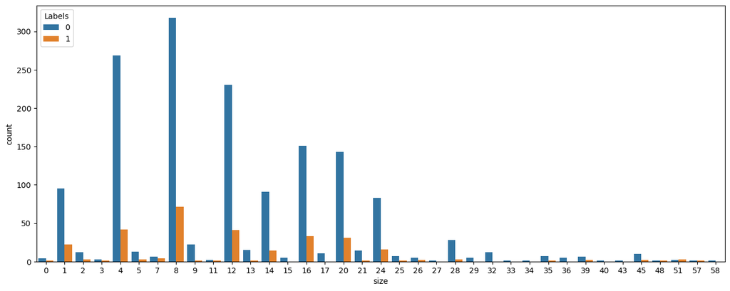

```python
plt.figure(figsize=[16, 6])
sns.countplot(df_hier['size'], hue='Labels', data=df_hier)
plt.show()
```

- Size 8 is most abundant in both clusters 0 and 1.
- CLuster 0 has more number of purchases as proved before.
- Count becomes almost similar in both clusters for products of larger sizes.

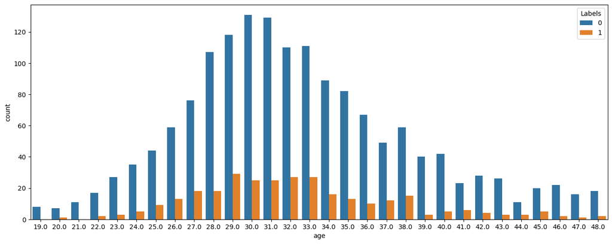

```python
plt.figure(figsize=[16, 6])
sns.countplot(df_hier['age'], hue='Labels', data=df_hier)
plt.show()
```

- For both clusters, more number of customers are between the ages 25 and 40 than any other age groups.

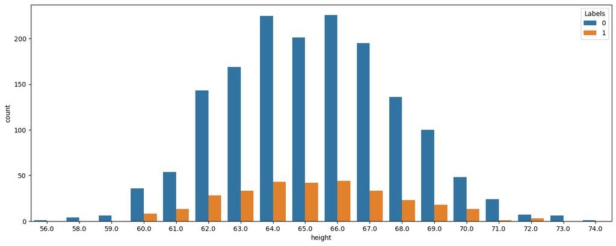

```python
plt.figure(figsize=[16, 6])
sns.countplot(df_hier['height'], hue='Labels', data=df_hier)
plt.show()
```

- For both clusters, more number of customers are between the heights 62 inches and 69 inches.